# Tidymodels Tutorial

## Introduction

Tidymodels is a collection of R packages that provides a unified framework for machine learning and statistical modeling. It follows tidy data principles and integrates seamlessly with the tidyverse ecosystem. This tutorial covers the core packages and workflow for building robust predictive models.

## Core Tidymodels Packages

### 1. **rsample** - Data Splitting and Resampling

Handles data partitioning, cross-validation, and bootstrap sampling.

### 2. **recipes** - Feature Engineering

Preprocesses data through a consistent interface for transformations.

### 3. **parsnip** - Model Specification

Provides a unified interface to different modeling engines.

### 4. **workflows** - Model Workflows

Combines preprocessing and modeling steps into a single object.

### 5. **tune** - Hyperparameter Tuning

Optimizes model parameters through grid search and other methods.

### 6. **yardstick** - Model Evaluation

Calculates performance metrics for model assessment.

### 7. **broom** - Model Tidying

Converts model outputs to tidy data frames.

### 8. **dials** - Parameter Definitions

Defines tuning parameters and their ranges.

## Complete Workflow Example

Let’s work through a complete machine learning workflow using the Palmer Penguins dataset to predict penguin species.

Setup and Data Loading

Data Splitting with rsample

Feature Engineering with recipes

Review processing steps

Model Specification with **parsnip**

Creating Workflows

Hyperparameter Tuning with **tune**: (1 of 3) Create a grid of potential parameter values.

Hyperparameter Tuning with **tune**: (2 of 3) Tune the random forest and logistic regressions

Hyperparameter Tuning with **tune**: (3 of 3) Show the tuning results.

Model Selection and Finalization: Select best models.

Model Evaluation with `yardstick` (1 of 3).

Model Evaluation with `yardstick`. (2 of 3)

Model Evaluation with `yardstick`. (3 of 3)

```r
# Load required libraries
library(tidymodels)
library(palmerpenguins)
library(vip)          # for variable importance
library(corrplot)     # for correlation plots

# Load and examine the data
data(penguins)
penguins <- penguins %>%
  drop_na()

glimpse(penguins)
```

```
Rows: 333
Columns: 8
$ species           <fct> Adelie, Adelie, Adelie, Adelie, Adelie, Adelie, Adel…
$ island            <fct> Torgersen, Torgersen, Torgersen, Torgersen, Torgerse…
$ bill_length_mm    <dbl> 39.1, 39.5, 40.3, 36.7, 39.3, 38.9, 39.2, 41.1, 38.6…
$ bill_depth_mm     <dbl> 18.7, 17.4, 18.0, 19.3, 20.6, 17.8, 19.6, 17.6, 21.2…
$ flipper_length_mm <int> 181, 186, 195, 193, 190, 181, 195, 182, 191, 198, 18…
$ body_mass_g       <int> 3750, 3800, 3250, 3450, 3650, 3625, 4675, 3200, 3800…
$ sex               <fct> male, female, female, female, male, female, male, fe…
$ year              <int> 2007, 2007, 2007, 2007, 2007, 2007, 2007, 2007, 2007…
```

```r
# Set seed for reproducibility
set.seed(123)

# Initial split (75% training, 25% testing)
penguin_split <- initial_split(penguins,
                              prop = 0.75,
                              strata = species)

penguin_train <- training(penguin_split)
penguin_test <- testing(penguin_split)

# Create cross-validation folds for tuning
penguin_folds <- vfold_cv(penguin_train,
                         v = 5,
                         strata = species)

cat("Training set size:", nrow(penguin_train), "\n")
```

```
Training set size: 249
```

```r
cat("Test set size:", nrow(penguin_test), "\n")
```

```
Test set size: 84
```

```r
# Create a recipe for preprocessing
penguin_recipe <- recipe(species ~ ., data = penguin_train) %>%
  # Remove unnecessary variables
  step_rm(island, year) %>%
  # Handle missing values (though we already removed them)
  step_impute_knn(all_predictors()) %>%
  # Normalize numeric variables
  step_normalize(all_numeric_predictors()) %>%
  # Create dummy variables for categorical predictors
  step_dummy(all_nominal_predictors()) %>%
  # Remove zero variance predictors
  step_zv(all_predictors())
```

```r
# Preview the preprocessing steps
print(penguin_recipe)
```

```
── Recipe ──────────────────────────────────────────────────────────────────────
```

```
── Inputs
```

```
Number of variables by role
```

```
outcome:   1
predictor: 7
```

```
── Operations
```

```
• Variables removed: island year
```

```
• K-nearest neighbor imputation for: all_predictors()
```

```
• Centering and scaling for: all_numeric_predictors()
```

```
• Dummy variables from: all_nominal_predictors()
```

```
• Zero variance filter on: all_predictors()
```

```r
# Random Forest specification
rf_spec <- rand_forest(
  mtry = tune(),          # number of variables to try at each split
  trees = 1000,           # number of trees
  min_n = tune()          # minimum observations per node
) %>%
  set_mode("classification") %>%
  set_engine("ranger", importance = "impurity")

# Multinomial Regression specification
multinom_spec <- multinom_reg(
  penalty = tune(),
  mixture = tune()
) %>%
  set_mode("classification") %>%
  set_engine("glmnet")

# XGBoost specification
xgb_spec <- boost_tree(
  trees = tune(),
  tree_depth = tune(),
  min_n = tune(),
  learn_rate = tune()
) %>%
  set_mode("classification") %>%
  set_engine("xgboost", objective = "multi:softprob")
```

```r
# Random Forest workflow
rf_workflow <- workflow() %>%
  add_recipe(penguin_recipe) %>%
  add_model(rf_spec)

# Logistic Regression workflow
multinom_workflow  <- workflow() %>%
  add_recipe(penguin_recipe) %>%
  add_model(multinom_spec)

# XGBoost workflow
xgb_workflow <- workflow() %>%
  add_recipe(penguin_recipe) %>%
  add_model(xgb_spec)
```

```r
# Define parameter grids
rf_grid <- grid_regular(
  mtry(range = c(1, 4)),
  min_n(range = c(2, 10)),
  levels = 3
)

logistic_grid <- grid_regular(
  penalty(range = c(-3, 0)),
  mixture(range = c(0, 1)),
  levels = 4
)
```

```r
# Tune Random Forest
set.seed(456)
rf_tuned <- rf_workflow %>%
  tune_grid(
    resamples = penguin_folds,
    grid = rf_grid,
    metrics = metric_set(accuracy, roc_auc, f_meas)
  )

# Tune Multinomial Regression
set.seed(456)
multinom_tuned <- multinom_workflow %>%
  tune_grid(
    resamples = penguin_folds,
    grid = logistic_grid,
    metrics = metric_set(accuracy, roc_auc, f_meas)
  )
```

```r
# View tuning results
show_best(rf_tuned, metric = "accuracy")
```

```
# A tibble: 5 × 8
   mtry min_n .metric  .estimator  mean     n std_err .config
  <int> <int> <chr>    <chr>      <dbl> <int>   <dbl> <chr>
1     1     2 accuracy multiclass 0.988     5 0.00497 Preprocessor1_Model1
2     1     6 accuracy multiclass 0.988     5 0.00497 Preprocessor1_Model4
3     1    10 accuracy multiclass 0.988     5 0.00497 Preprocessor1_Model7
4     2     2 accuracy multiclass 0.980     5 0.00633 Preprocessor1_Model2
5     2     6 accuracy multiclass 0.976     5 0.00398 Preprocessor1_Model5
```

```r
show_best(multinom_tuned, metric = "accuracy")
```

```
# A tibble: 5 × 8
  penalty mixture .metric  .estimator  mean     n std_err .config
    <dbl>   <dbl> <chr>    <chr>      <dbl> <int>   <dbl> <chr>
1   0.001   0.333 accuracy multiclass 0.996     5 0.00400 Preprocessor1_Model05
2   0.001   0.667 accuracy multiclass 0.996     5 0.00400 Preprocessor1_Model09
3   0.001   1     accuracy multiclass 0.992     5 0.00490 Preprocessor1_Model13
4   0.01    0.333 accuracy multiclass 0.988     5 0.00804 Preprocessor1_Model06
5   0.01    0.667 accuracy multiclass 0.988     5 0.00804 Preprocessor1_Model10
```

```r
# Select best models
best_rf <- select_best(rf_tuned, metric = "accuracy")
best_multinom <- select_best(multinom_tuned, metric = "accuracy")

# Finalize workflows
final_rf_workflow <- rf_workflow %>%
  finalize_workflow(best_rf)

final_multinom_workflow <- multinom_workflow %>%
  finalize_workflow(best_multinom)

# Fit on training data and evaluate on test set
rf_final_fit <- final_rf_workflow %>%
  last_fit(penguin_split)

multinom_final_fit <- final_multinom_workflow %>%
  last_fit(penguin_split)
```

```r
# Extract test set predictions and metrics
rf_test_results <- rf_final_fit %>% collect_metrics()
multinom_test_results <- multinom_final_fit %>% collect_metrics()

# Display results
cat("Random Forest Test Accuracy:",
    rf_test_results %>% filter(.metric == "accuracy") %>% pull(.estimate), "\n")
```

```
Random Forest Test Accuracy: 1
```

```r
cat("Multinomial Regression Test Accuracy:",
    multinom_test_results %>% filter(.metric == "accuracy") %>% pull(.estimate), "\n")
```

```
Multinomial Regression Test Accuracy: 1
```

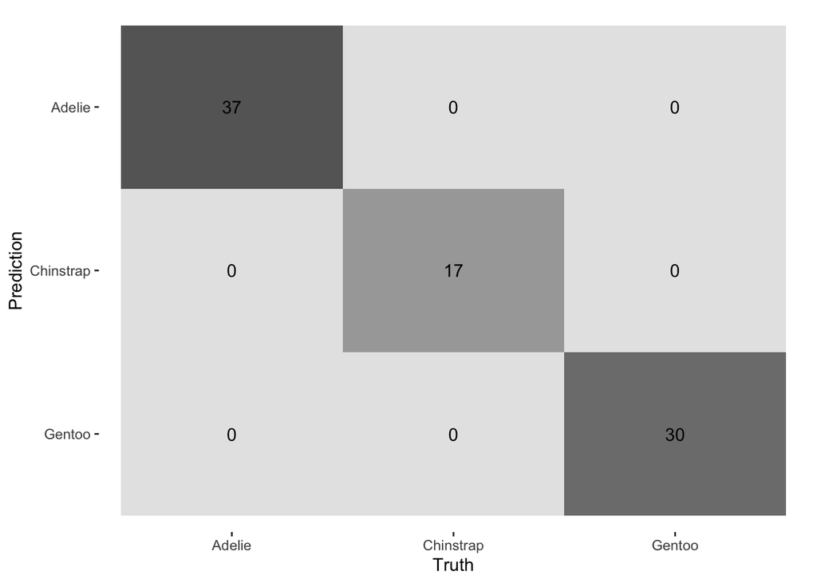

```r
# Confusion matrices
rf_final_fit %>%
  collect_predictions() %>%
  conf_mat(species, .pred_class) %>%
  autoplot(type = "heatmap")
```

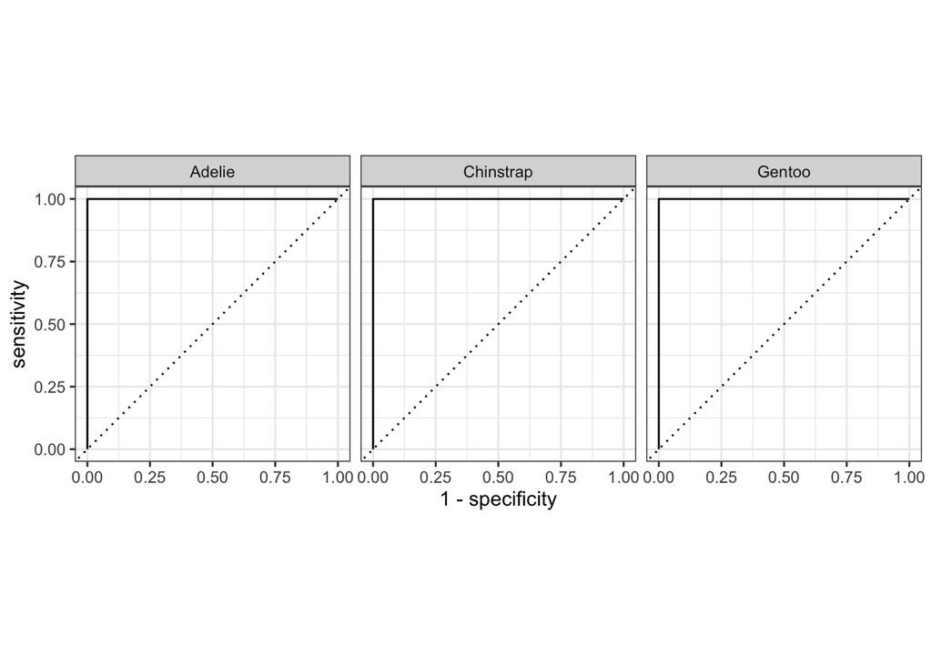

```r
# ROC curves for multi-class
rf_final_fit %>%
  collect_predictions() %>%
  roc_curve(species, .pred_Adelie:.pred_Gentoo) %>%
  autoplot()
```

## Best Practices

### 1. **Always Use Proper Data Splitting**

- Use stratified sampling for imbalanced datasets
- Create validation sets for model comparison
- Keep test set untouched until final evaluation

### 2. **Preprocessing Consistency**

- Apply the same preprocessing to training and test data
- Use recipes to ensure reproducible preprocessing
- Handle missing data appropriately

### 3. **Model Validation**

- Use cross-validation for hyperparameter tuning
- Compare multiple models systematically
- Evaluate on multiple metrics

### 4. **Reproducibility**

- Set random seeds consistently
- Document preprocessing steps
- Version control your analysis